# Origens dos estudantes de intercâmbio nos EUA

Douglas H. Novelli

## 1. Introdução

O estudo visa verificar se o número de indivíduos matriculados em instituições de ensino estadunidenses está relacionado a região sociopolítica de seus países de origem.

Utiliza o pacote `tidyverse`, para limpeza e organização dos dados; e os pacotes `rstatix` e `stats`, para realização de parte de suas análises estatísticas.

```r
library(tidyverse)
library(rstatix)
library(stats)
```

## 2. Importação e limpeza dos dados

Serão utilizados três conjuntos de dados:

1. Número e local de origem dos estudantes extrangeiros em instituições de ensino estadunidenses, empregando dados da instituição [Open Doors](https://opendoorsdata.org/);
2. População de cada Estado, empregando dados do [Banco Mundial](https://data.worldbank.org/indicator/SP.POP.TOTL); e
3. Região sociopolítica, definida com base nos [grupos regionais das Nações Unidas](https://www.un.org/dgacm/en/content/regional-groups).

Os dados em questão foram coletados previamente, sendo disponibilizados na pasta `/datasets`.

É feita a opção por trabalhar com dados de 2019, haja visto que a pandemia de COVID-19 pode ter tido efeitos inesperados sobre o número de estudantes estrangeiros.

```r
students <- read_csv2("datasets/census.csv") %>%
  select("Place of Origin", "2019/20") %>%
  rename("n_students" = "2019/20") %>%
  mutate(n_students = as.numeric(n_students))

population <- read_csv2("datasets/population.csv") %>%
  select("Country Name", "2019") %>%
  rename("total_pop" = "2019")

un_group <- read_csv2("datasets/un_group.csv")
```

Uma primeira tentativa de junção dos dados resulta em um banco de dados com 164 observações completas, ao invés das 192 esperadas (193 Estados-membros da ONU, menos os EUA), revelando problemas na padronização de suas nomenclaturas.

```r
df <- un_group %>%
  left_join(population, by = c("Country" = "Country Name")) %>%
  left_join(students, by = c("Country" = "Place of Origin"))

count(drop_na(df))
```

```
## # A tibble: 1 × 1
##       n
##   <int>
## 1   164
```

Os blocos de códigos abaixo listam os Estados cuja nomenclatura precisa ser padronizada:

```r
#population
df %>%
  filter(is.na(total_pop)) %>%
  select(Country) %>%
  arrange(Country)
```

```
## # A tibble: 21 × 1
##    Country
##    <chr>
##  1 Bolivia (Plurinational State of)
##  2 Congo
##  3 Côte d'Ivoire
##  4 Democratic People's Republic of Korea
##  5 Democratic Republic of the Congo
##  6 Iran (Islamic Republic of)
##  7 Kyrgyzstan
##  8 Lao People's Democratic Republic
##  9 Micronesia (Federated States of)
## 10 Republic of Korea
## # … with 11 more rows
```

```r
#students
df %>%
  filter(is.na(n_students)) %>%
  select(Country) %>%
  arrange(Country)
```

```
## # A tibble: 27 × 1
##    Country
##    <chr>
##  1 Bolivia (Plurinational State of)
##  2 Brunei Darussalam
##  3 Congo
##  4 Côte d'Ivoire
##  5 Czechia
##  6 Democratic People's Republic of Korea
##  7 Democratic Republic of the Congo
##  8 Gambia
##  9 Iran (Islamic Republic of)
## 10 Lao People's Democratic Republic
## # … with 17 more rows
```

A partir dessas listas, se extrai as seguintes alterações, necessárias para a padronização da base:

```r
un_group <- un_group %>%
  mutate(
    Country = recode(Country,
                     "Bolivia (Plurinational State of)" = "Bolivia",
                     "Iran (Islamic Republic of)" = "Iran",
                     "Micronesia (Federated States of)" = "Micronesia",
                     "Republic of Moldova" = "Moldova",
                     "Saint Kitts and Nevis" = "St. Kitts and Nevis",
                     "Saint Lucia" = "St. Lucia",
                     "Saint Vincent and the Grenadines" = "St. Vincent and the Grenadines",
                     "United Kingdom of Great Britain and Northern Ireland" = "United Kingdom",
                     "United Republic of Tanzania" = "Tanzania",
                     "Venezuela (Bolivarian Republic of)" = "Venezuela",
                     "Viet Nam" = "Vietnam")
  )

population <- population %>%
  rename(Country = `Country Name`) %>%
  mutate(
    Country = recode(Country,
                     "Rep. Congo" = "Congo",
                     "Cote d'Ivoire" = "Côte d'Ivoire",
                     "Korea ( Dem. People's Rep.)" = "Democratic People's Republic of Korea",
                     "Dem. Rep. Congo" = "Democratic Republic of the Congo",
                     "Kyrgyz Republic" = "Kyrgyzstan",
                     "Lao PDR" = "Lao People's Democratic Republic",
                     "Korea (Rep.)" = "Republic of Korea",
                     "Slovak Republic" = "Slovakia",
                     "Turkiye" = "Türkiye")
  )

students <- students %>%
  rename(Country = `Place of Origin`) %>%
  mutate(
    Country = recode(Country,
                     "Brunei" = "Brunei Darussalam",
                     "Congo, Republic of the (Brazzaville)" = "Congo",
                     "Côte d’Ivoire" = "Côte d'Ivoire",
                     "Czech Republic" = "Czechia",
                     "North Korea" = "Democratic People's Republic of Korea",
                     "Congo, Dem. Rep. of the (Kinshasa)" = "Democratic Republic of the Congo",
                     "Gambia, The" = "Gambia",
                     "Laos" = "Lao People's Democratic Republic",
                     "Marshall Islands, Republic of the" = "Marshall Islands",
                     "Micronesia, Federate States of" = "Micronesia",
                     "Burma" = "Myanmar",
                     "South Korea" = "Republic of Korea",
                     "Russia" = "Russian Federation",
                     "São Tomé & Príncipe" = "Sao Tome and Principe",
                     "Syria" = "Syrian Arab Republic",
                     "Turkey" = "Türkiye")
  )
```

Com o nome dos países padronizado, se procede para a junção final dos bancos dados, o qual agora registra o número correto de notações.

```r
df <- un_group %>%
  left_join(population, by = "Country") %>%
  left_join(students, by = "Country") %>%
  drop_na()

count(df)
```

```
## # A tibble: 1 × 1
##       n
##   <int>
## 1   192
```

A limpeza e organização do banco de dados é concluída com a criação da variável de interesse, `students_100k`, calculada a partir das variáveis `n_students` e `total_pop`. Aproveita-se, também, para reduzir as categorias da variável `UN group` às siglas de cada grupo regional, o que facilitará a visualização futura dos dados.

```r
df <- df %>%
  mutate(students_100k = (n_students*100000)/total_pop) %>%
  rename(country = Country, un_group = `UN group`) %>%
  select(country, un_group, students_100k) %>%
  mutate(un_group = recode(un_group,
                           "African Group" = "AG",
                           "Asia and Pacific Group" = "APG",
                           "Eastern European Group (EEG)" = "EEG",
                           "Latin American and Caribbean Group (GRULAC)" = "GRULAC",
                           "Western European and other States Group (WEOG)" = "WEOG"))

df %>%
  arrange(desc(students_100k)) %>%
  head()
```

```
## # A tibble: 6 × 3
##   country             un_group students_100k
##   <chr>               <chr>            <dbl>
## 1 Dominica            GRULAC            806.
## 2 Bahamas             GRULAC            618.
## 3 St. Kitts and Nevis GRULAC            453.
## 4 Antigua and Barbuda GRULAC            210.
## 5 Palau               APG               190.
## 6 Kuwait              APG               189.
```

## 3. Exploração inicial dos dados

Via de regra, a análise de variância (ANOVA) demanda que os dados não apresentem outliers. Isso pode ser verificado através da função `rstatix::identify_outliers()`, assim como através de um gráfico de boxplot.

```r
df %>%
  group_by(un_group) %>%
  identify_outliers(students_100k)
```

```
## # A tibble: 16 × 5
##    un_group country             students_100k is.outlier is.extreme
##    <chr>    <chr>                       <dbl> <lgl>      <lgl>
##  1 AG       Equatorial Guinea            15.9 TRUE       FALSE
##  2 AG       Eswatini                     14.9 TRUE       FALSE
##  3 AG       Mauritius                    26.2 TRUE       TRUE
##  4 APG      Kuwait                      189.  TRUE       TRUE
##  5 APG      Palau                       190.  TRUE       TRUE
##  6 APG      Republic of Korea            96.2 TRUE       FALSE
##  7 APG      Saudi Arabia                 86.4 TRUE       FALSE
##  8 APG      Singapore                    79.0 TRUE       FALSE
##  9 APG      Tonga                       153.  TRUE       TRUE
## 10 EEG      Albania                      38.4 TRUE       TRUE
## 11 GRULAC   Bahamas                     618.  TRUE       TRUE
## 12 GRULAC   Dominica                    806.  TRUE       TRUE
## 13 GRULAC   St. Kitts and Nevis         453.  TRUE       TRUE
## 14 WEOG     Canada                       69.1 TRUE       TRUE
## 15 WEOG     Iceland                     114.  TRUE       TRUE
## 16 WEOG     Monaco                       54.0 TRUE       FALSE
```

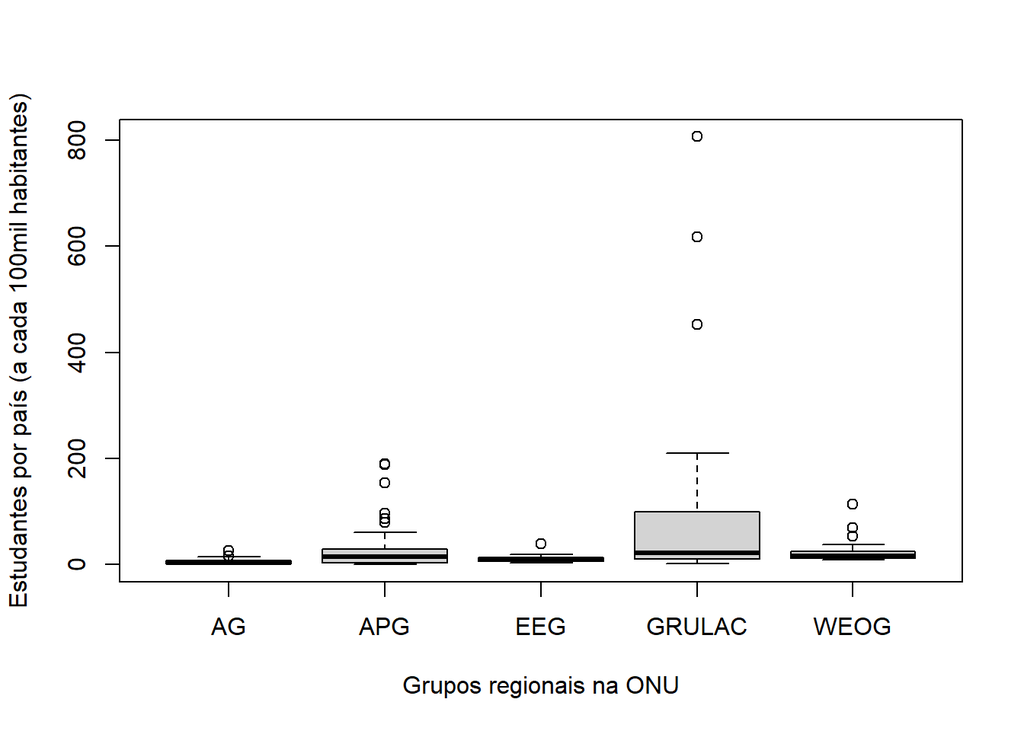

```r
boxplot(students_100k ~ un_group, data = df,
        ylab = "Estudantes por país (a cada 100mil habitantes)",
        xlab = "Grupos regionais na ONU")
```

Foi possível identificar a presença de 16 observações contendo outliers, sendo que 10 dessas são outliers extremos. Adicionalmente, o boxplot revela que a distribuição dos dados é altamente distorcida, com uma longa cauda de um lado e a maior parte dos dados se agrupando do outro, sugerindo que uma transformação logarítmica pode ajudar na melhor visualização de um padrão nos dados.

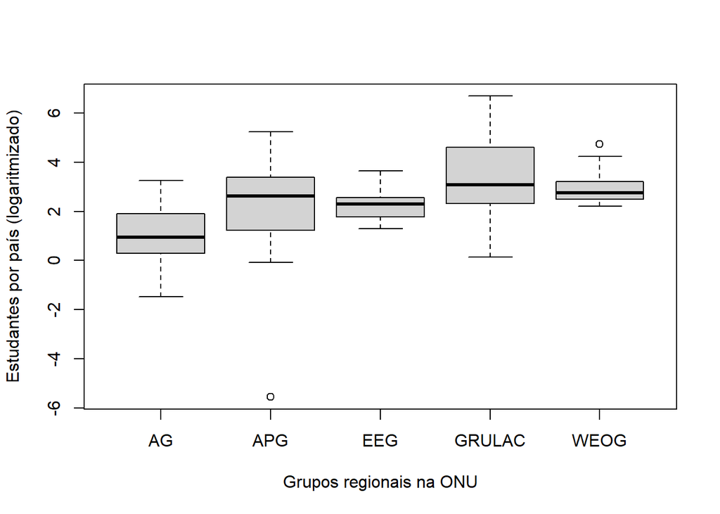

```r
df <- df %>%
  mutate(students_log = log(students_100k))

boxplot(students_log ~ un_group, data = df,
        ylab = "Estudantes por país (logaritmizado)",
        xlab = "Grupos regionais na ONU")
```

```r
df %>%
  group_by(un_group) %>%
  identify_outliers(students_log)
```

```
## # A tibble: 2 × 6
##   un_group country                               stude…¹ stude…² is.ou…³ is.ex…⁴
##   <chr>    <chr>                                   <dbl>   <dbl> <lgl>   <lgl>
## 1 APG      Democratic People's Republic of Korea 3.88e-3   -5.55 TRUE    TRUE
## 2 WEOG     Iceland                               1.14e+2    4.74 TRUE    FALSE
## # … with abbreviated variable names ¹students_100k, ²students_log, ³is.outlier,
## #   ⁴is.extreme
```

O boxplot resultante ainda revela dois outliers, sendo que um deles (Coréia do Norte) trata-se de um caso extremo, o qual pode ter grande impacto no modelo. Assim, opta-se pela exclusão desses dados previamente à realização da análise de variância.

```r
df <- df %>%
  filter(country != "Democratic People's Republic of Korea")
```

## 4. Análise de variância

Para realização do teste de variância (ANOVA), aplica-se a função `aov()`, incluída como parte do R base. Além da localização da base de dados, ela leva como argumentos a variável de interesse, `students_log`, e a variável preditora, `un_group`.

```r
modelo <- aov(students_log ~ un_group, data = df)
summary(modelo)
```

```
##              Df Sum Sq Mean Sq F value Pr(>F)
## un_group      4  145.7   36.42   25.86 <2e-16 ***
## Residuals   186  261.9    1.41
## ---
## Signif. codes:  0 '***' 0.001 '**' 0.01 '*' 0.05 '.' 0.1 ' ' 1
```

Os resultados do teste ANOVA mostram que há uma diferença significativa entre as médias dos grupos regionais. O valor de F de 25.86 e o valor p de 2e-16 sugerem que essa diferença é estatisticamente significativa, rejeitando a hipótese nula de que todas as médias seriam iguais.

Visando identificar quais grupos apresentam médias diferentes, é realizado o teste posthoc de Tukey, fornecido pela função `stats::TukeyHSD`.

```r
TukeyHSD(modelo)
```

```
##   Tukey multiple comparisons of means
##     95% family-wise confidence level
##
## Fit: aov(formula = students_log ~ un_group, data = df)
##
## $un_group
##                   diff        lwr       upr     p adj
## APG-AG       1.5021689  0.8700764 2.1342615 0.0000000
## EEG-AG       1.2307398  0.4167703 2.0447093 0.0004531
## GRULAC-AG    2.4011783  1.6788588 3.1234978 0.0000000
## WEOG-AG      1.9638525  1.2025547 2.7251504 0.0000000
## EEG-APG     -0.2714291 -1.0876891 0.5448309 0.8904600
## GRULAC-APG   0.8990094  0.1741097 1.6239090 0.0069025
## WEOG-APG     0.4616836 -0.3020627 1.2254299 0.4580267
## GRULAC-EEG   1.1704385  0.2824717 2.0584052 0.0033210
## WEOG-EEG     0.7331127 -0.1868405 1.6530659 0.1860599
## WEOG-GRULAC -0.4373258 -1.2772740 0.4026224 0.6063723
```

Considerando os valores ajustados do valor-p, verifica-se que:

- O Grupo Africano (AG) apresenta uma diferença com significância estatística < 0.001 com todos os demais grupos;
- O Grupo Latino-Americano e Caribenho (GRULAC) também apresenta diferenças com significância estatística < 0.01 com os grupos da Ásia e Pacífico (APG) e dos Estados do Leste Europeu (EEG);
- As demais combinações apresentaram um valor-p muito superior a 0.05, indicando que não é possível afirmar a existencia de diferença significativa entre esses grupos.

O gráfico abaixo resume as os valores referentes a cada grupo, apresentando as médias no eixo y, junto com suas barras de erro.

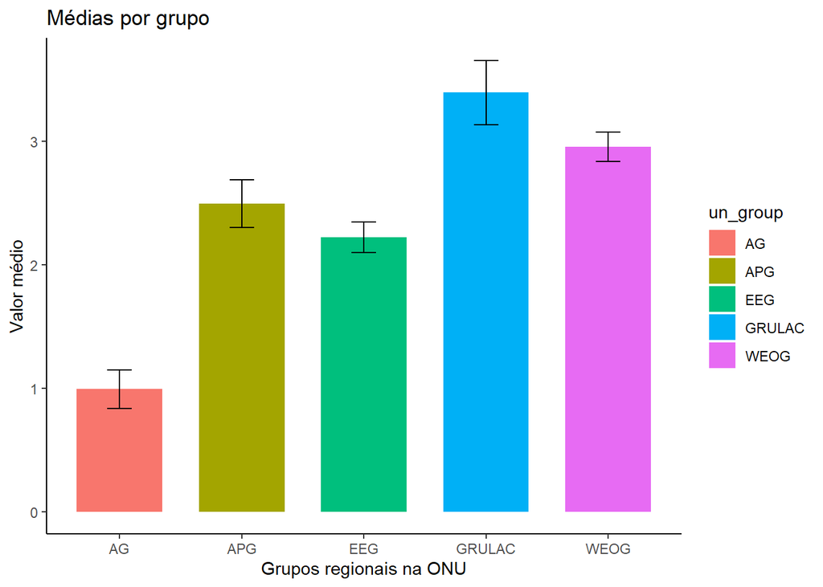

```r
summary_stats <- df %>%
  group_by(un_group) %>%
  summarize(mean = mean(students_log),
            sd = sd(students_log),
            n = n())

ggplot(summary_stats, aes(x = un_group, y = mean, fill = un_group)) +
  geom_col(width = 0.7) +
  geom_errorbar(aes(ymin = mean - sd/sqrt(n), ymax = mean + sd/sqrt(n)), width = 0.2) +
  labs(x = "Grupos regionais na ONU", y = "Valor médio", title = "Médias por grupo") +
  theme_classic()
```

## 5. Conclusões

Baseado nos resultados da análise, é possível afirmar que o número de indivíduos matriculados em instituições de ensino estadunidenses de fato está relacionado a região sociopolítica de seus países de origem.

Comparado aos demais grupos, é possível notar um efeito negativo no Grupo Africano (AG); enquanto o Grupo Latino-Americano e Caribenho (GRULAC) parece ter um efeito positivo, embora esse não seja significante quando feita a comparação com o grupo da Europa Ocidental e Outros (WEOG).